# Gemischte Lineare Regression

[figure not shown]

Auf dieser Seite findest du Übungen zu Gemischten Modellen in R.

Der gesamte Code, den du hier findest, kann von dir 1:1 in R umgesetzt werden. Die größte Lernwirkung hat diese Einführung, wenn du möglichst alles einmal selbst in R durchführst.

# 01 Vorbereitungen

Bevor wir loslegen können, müssen wir die Packages laden, die wir für unser Vorhaben benötigen. Neben dem `SfL` Package laden wir zusätzliche Packages, mit denen wir Gemischte Modelle erstellen können:

```r
install.packages("lme4")
install.packages("lmerTest")
install.packages("LMERConvenienceFunctions")
```

```r
library(SfL)
library(lme4)
library(lmerTest)
library(LMERConvenienceFunctions)
```

**Hinweis:** Solltest du im späteren Verlauf feststellen, dass dir keine p-Werte angezeigt werden, führe folgenden Schritt zur manuellen Installation einer früheren Version des Packages durch:

```r
require(devtools)
install_version("lme4", version = "1.1.23", repos = "http://cran.us.r-project.org")
```

Führe diesen Schritt wirklich nur dann aus, wenn du später keine p-Werte angezeigt bekommst!

Nun laden wir die Datensätze, die wir nutzen werden:

```r
data(data_s)
data(data_v)
```

# 02 Einführung

Die Nutzung von Gemischten Modellen ist im Vergleich zu anderen Methoden aufwendig. Aber lohnt sich der Aufwand?

Hierzu werfen wir einen Blick auf die Beispiel-Daten zu Kindern und ihrem Wachstum aus dem Theorie-Teil. Achtung: Die Daten sind nicht Teil des `SfL` Packages und dienen hier nur Illustrationszwecken.

```r
height_e <- lm(height ~ age, data_h) # Einfache

height_m <- lm(height ~ age + bsex, data_h) # Multiple

height_l1 <- lmer(height ~ age + bsex + (1|name), data_h, REML=F) # Gemischte mit Random Intercept

height_l2 <- lmer(height ~ age + bsex + (age|name), data_h, REML=F) # Gemischte mit Random Intercept & Random Slope
```

Hier haben wir nun also ein Einfaches Lineares Modell, ein Multiples Lineares Modell, ein Gemischtes Modell mit Random Intercept und ein Gemischtes Modell mit Random Intercecpt sowie Random Slope. Wie schneiden diese Modelle ab?

```r
AIC(height_e, height_m, height_l1, height_l2)
```

```
          df      AIC
height_e   3 284.4112
height_m   4 279.4706
height_l1  5 255.5833
height_l2  7 248.3431
```

Wir wir sehen, nimmt der AIC-Wert von oben nach unten ab. Demnach werden die Modelle mit zunehmender Komplexität besser, und das Gemischte Modell mit Random Intercept und Random Slope beschreibt die Daten am besten.

# 03 Vorbereitung der Daten

Wir möchten `sDur` anhand der folgenden Variablen modelln:

`baseDur`, `speakingRate`, `googleFreq`, `age`, `speaker`, `typeOfS`, `folSeg`, `folType`, `item`, `transcription`, `biphoneProbSum`, `biphoneProbSumBin`, `monoMultilingual`, `pauseBin`, `preC`

Hierzu müssen wir zunächst einige Dinge überprüfen.

## Überprüfung der Verteilung

Wie wir bereits wissen, ist die Verteilung der Daten ein entscheidender Punkt. Daher checken wir die Verteilung der folgenden numerischen Variablen mit Shapiro-Wilk Tests:

`sDur`, `baseDur`, `speakingRate`, `googleFreq`

### sDur

```r
shapiro.test(data_s$sDur)
```

```
    Shapiro-Wilk normality test

data:  data_s$sDur
W = 0.93622, p-value = 2.761e-06
```

Mit $p=2.761e^{-6}<0.05$, ist `sDur` nicht normalverteilt.

```r
data_s$sDurLog <- log(data_s$sDur)

shapiro.test(data_s$sDurLog)
```

```
    Shapiro-Wilk normality test

data:  data_s$sDurLog
W = 0.9927, p-value = 0.6438
```

Mit $p=0.6438>0.05$, ist `sDurLog` normalverteilt.

### baseDur

```r
shapiro.test(data_s$baseDur)
```

```
    Shapiro-Wilk normality test

data:  data_s$baseDur
W = 0.90932, p-value = 4.606e-08
```

Mit $p=4.606e^{-8}<0.05$, ist `baseDur` nicht normalverteilt.

```r
data_s$baseDurLog <- log(data_s$baseDur)

shapiro.test(data_s$baseDurLog)
```

```
    Shapiro-Wilk normality test

data:  data_s$baseDurLog
W = 0.98401, p-value = 0.07966
```

Mit $p=0.07966>0.05$, ist `baseDurLog` normalverteilt.

### speakingRate

```r
shapiro.test(data_s$speakingRate)
```

```
    Shapiro-Wilk normality test

data:  data_s$speakingRate
W = 0.96027, p-value = 0.0002596
```

Mit $p=0.0003<0.05$, ist `speakingRate` nicht normalverteilt.

```r
data_s$speakingRateLog <- log(data_s$speakingRate)

shapiro.test(data_s$speakingRateLog)
```

```
    Shapiro-Wilk normality test

data:  data_s$speakingRateLog
W = 0.99308, p-value = 0.6884
```

Mit $p=0.6884>0.05$, ist `speakingRateLog` normalverteilt.

### googleFreq

```r
shapiro.test(data_s$googleFreq)
```

```
    Shapiro-Wilk normality test

data:  data_s$googleFreq
W = 0.3621, p-value < 2.2e-16
```

Mit $p=2.2e^{-16}<0.05$, ist `googleFreq` nicht normalverteilt.

```r
data_s$googleFreqLog <- log(data_s$googleFreq)

shapiro.test(data_s$googleFreqLog)
```

```
    Shapiro-Wilk normality test

data:  data_s$googleFreqLog
W = 0.97312, p-value = 0.004867
```

Mit $p=0.004867<0.05$, `googleFreqLog` nicht normalverteilt. Allerdings ist die Verteilung von `googleFreqLog` dennoch näher an einer Normalverteilung:

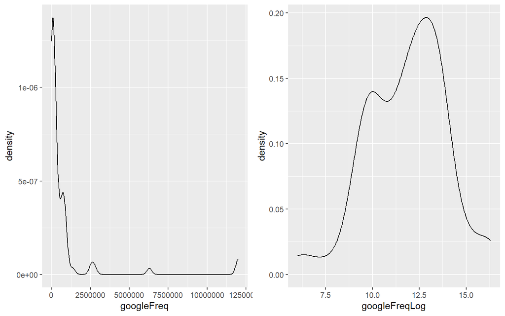

## Überprüfung der Korrelationen

Wie wir bereits wissen, ist Kollinearität ein Problem für Modelle mit vielen Prediktorvariablen. Daher testen wir zunächst die Korrelation der Variablen.

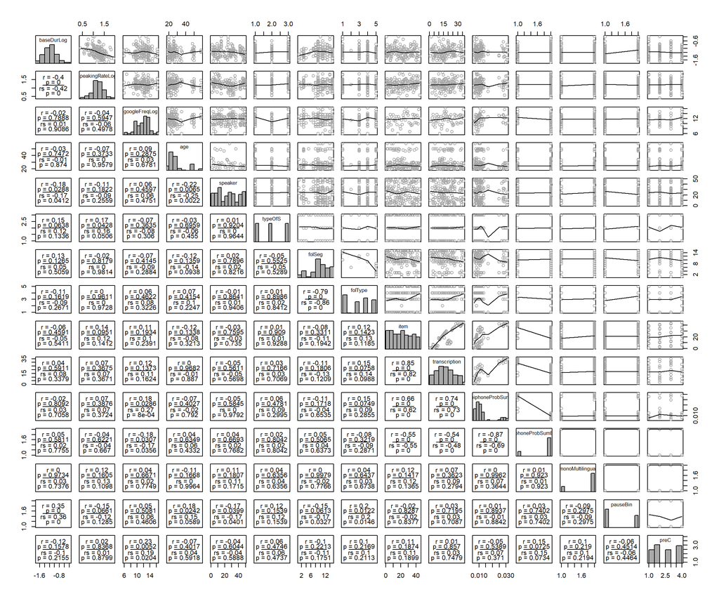

```r
correlation_matrix(data = data_s,
                   variables = c("baseDurLog", "speakingRateLog", "googleFreqLog",
                                 "age", "speaker", "typeOfS", "folSeg", "folType", "item", "transcription", "biphoneProbSum",  "biphoneProbSumBin", "monoMultilingual", "pauseBin", "preC"))
```

Betrachten wir die Korrelationskoeffizienten näher, finden wir folgende problematische Fälle:

- `folSeg` vs. `folType`
- `biphoneProbSumBin` vs. `biphoneProbSum`
- `biphoneProbSumBin` vs. `item`
- `biphoneProbSumBin` vs. `transcriptions`
- `biphoneProbSum` vs. `item`
- `biphoneProbSum` vs. `transcription`
- `item` vs. `transcription`

Im nächsten Schritt nutzen wir die “Vergleich und Ausschluss”-Strategie zur Vermeidung von Kollinearitätsproblemen.

## Vergleich und Ausschluss

**Idee:** Die stark korrelierten Variablen werden in simple Modelle eingesetzt und diese dann vergliechen. Die Variable mit der jeweils größeren Vorhersagekraft wird behalten.

**Potentielles Problem:** Der Verlust von Variablen kann einem Verlust an Vorhersagekraft entsprechen.

**Vorgehen:** Mit der `predictor_competition()` Funktion des `SfL` Packages kann herausgefunden werden, welche Variable der jeweils bessere Prediktor ist. Alternativ kann dieses Vorgehen auch manuell durchgeführt werden.

Da wir diesmal mit Gemischten Modellen arbeiten, spezifizieren wir im `predictor_competition()` Befehl auch einen Random Intercept.

### Schritt 1

`folSeg` vs. `folType`

```r
predictor_competition2(data = data_s,
                      dependent = "sDurLog",
                      independent1 = "folSeg",
                      independent2 = "folType",
                      random.intercept = "speaker")
```

```
     df      AIC
mdl1 17 140.8614
mdl2  7 135.7386
```

Wir haben einen Sieger: `folType`. Weitere Vergleiche mit `folSeg` entfallen.

### Schritt 2

`biphoneProbSumBin` vs. `biphoneProbSum`

```r
predictor_competition2(data = data_s,
                      dependent = "sDurLog",
                      independent1 = "biphoneProbSumBin",
                      independent2 = "biphoneProbSum",
                      random.intercept = "speaker")
```

```
     df      AIC
mdl1  4 130.3216
mdl2  4 129.7262
```

Wie vom Output angedeutet, sind beide Variablen gleich gute Prediktoren. In diesem Fall können wir wählen, welchen wir für die weitere Analyse behalten möchten.

Wir behalten `biphoneProbSum`. Weitere Vergleiche mit `biphoneProbSumBin` entfallen.

### Schritt 3

`item` vs. `transcription`

**Achtung**: Diese Variablen möchten wir als Random Effects einsetzen. Daher wäre eine Korrelation an sich kein Problem. Da wir allerdings wissen, dass beide Variablen in ihrer Bedeutung - und somit auch Aussagekraft - sehr ähnlich sind, entscheiden wir uns ganz ohne “statistische Probleme” für eine der beiden Variablen: `transcription`.

### Schritt 4

`biphoneProbSum` vs. `transcription`

**Achtung**: Da wir eine der beiden Variablen als Fixed Effect und die andere als Random Effect nutzen möchten, müssen wir keine Kollinearitätsprobleme befürchten. Entsprechend muss keine der beiden Variablen aussortiert werden.

## Zwischenergebnis

Zu Beginn haben wir problematische Korrelationen zwischen folgenden Variablen gefunden:

- `folSeg` vs. `folType`
- `biphoneProbSumBin` vs. `biphoneProbSum`
- `biphoneProbSumBin` vs. `item`
- `biphoneProbSumBin` vs. `transcriptions`
- `biphoneProbSum` vs. `item`
- `biphoneProbSum` vs. `transcription`
- `item` vs. `transcription`

Nach dem Anwenden der “Vergleich und Auschluss”-Strategie sind folgende Variablen erhalten geblieben: `folType`, `biphoneProbSum`, und `transcription`.

# 04 Volles Modell

Mit den Variablen, die das Ausschlussverfahren überlebt haben, sowie mit den Variablen, die keine problematischen Korrelationen gezeigt haben, kann nun ein volles Modell erstellt werden:

```r
mdl_full <- lmer(sDurLog ~
                   folType +
                   biphoneProbSum +
                   baseDurLog +
                   speakingRateLog +
                   googleFreqLog +
                   age +
                   typeOfS +
                   monoMultilingual +
                   pauseBin +
                   preC +
                   (1 | speaker) +
                   (1 | transcription),
                 data_s, REML=F)
```

# 05 Bestes Modell

Mit der `step()` Funktion können wir erneut das beste Modell finden:

```r
step(mdl_full)
```

```
Backward reduced random-effect table:

                    Eliminated npar   logLik    AIC     LRT Df Pr(>Chisq)
<none>                           20  -6.3749 52.750
(1 | transcription)          1   19  -6.3752 50.750  0.0008  1     0.9781
(1 | speaker)                0   18 -15.5262 67.052 18.3020  1  1.885e-05 ***
---
Signif. codes:  0 '***' 0.001 '**' 0.01 '*' 0.05 '.' 0.1 ' ' 1

Backward reduced fixed-effect table:
Degrees of freedom method: Satterthwaite

                 Eliminated  Sum Sq Mean Sq NumDF   DenDF F value    Pr(>F)
preC                      1 0.16862 0.05621     3 124.653  1.1940  0.314902
age                       2 0.04662 0.04662     1  28.033  0.9408  0.340359
googleFreqLog             3 0.11108 0.11108     1 125.054  2.2381  0.137166
folType                   4 0.42808 0.10702     4 133.867  2.0869  0.085967 .
biphoneProbSum            0 0.40410 0.40410     1 131.726  7.3133  0.007749 **
baseDurLog                0 1.45686 1.45686     1 144.633 26.3656 8.971e-07 ***
speakingRateLog           0 0.25002 0.25002     1 146.146  4.5247  0.035087 *
typeOfS                   0 1.21841 0.60921     2 136.646 11.0251 3.640e-05 ***
monoMultilingual          0 0.25425 0.25425     1  28.866  4.6012  0.040496 *
pauseBin                  0 1.70080 1.70080     1 137.036 30.7803 1.440e-07 ***
---
Signif. codes:  0 '***' 0.001 '**' 0.01 '*' 0.05 '.' 0.1 ' ' 1

Model found:
sDurLog ~ biphoneProbSum + baseDurLog + speakingRateLog + typeOfS + monoMultilingual + pauseBin + (1 | speaker)
```

Zuerst stellen wir fest, dass `transcription` als Random Intercept nicht benötigt wird.

Dann sehen wir, dass `preC`, `age`, `googleFreqLog` und `folType` keine signifikanten Prediktoren für `sDurLog` sind, und demnach aussortiert werden können.

Das beste Modell ist demnach folgendes:

```r
mdl_best <- lmer(sDurLog ~
                   biphoneProbSum +
                   baseDurLog +
                   speakingRateLog +
                   typeOfS +
                   monoMultilingual +
                   pauseBin +
                   (1 | speaker),
                 data_s, REML=F)
```

# 06 Diagnostik / Trimming

Gemischte Modelle folgenden den gleichen Assumptions, denen auch Simple und Multiple Lineare Regressionsmodelle folgen. Da wir bereits einige Male gesehen haben, wie man diese überprüft, sparen wir uns diesen Schritt hier.

Stattdessen schauen wir uns an, wie das finale Modell noch ein wenig besser gemacht werden kann: durch Residual Trimming.

Durch Residual Trimming wird der “Fit” des Modells verbessert, da Datenpunkte entfernt werden, die durch das Modell nur sehr schlecht erklärt werden können. Anders als das Aussortieren von Outliern vor dem Modell-Prozess ist dieses Vorgehen statistisch motiviert und entspricht modernen Konventionen.

Nachdem man, so wie im vorliegenden Fall, ein “bestes” Modell gefunden hat, kann man mit dem `LMERConvenienceFunctions` Package die Daten trimmen:

```r
library(LMERConvenienceFunctions)

data_s2 <- romr.fnc(mdl_best, # das beste Modell
                    data_s, # der Datensatz
                    trim = 2.5) # die Standardabweichung mit welcher man trimmen möchte; 2.5 ist die Standardeinstellung
```

```
n.removed = 1
percent.removed = 0.6666667
```

Mit diesem Befehl trimmt man die Daten, deren Residuen im Modell $2.5$ oder mehr Standardabweichungen vom Durchschnitt der Gesamtresiduen entfernt liegen.

Im vorliegenden Fall wird lediglich $1$ Datenpunkt getrimmt, d.h. $0.67/%$ der gesamten Datenmenge.

Anschließend wird das getrimmte Datenset im Environment gesichert:

```r
data_s2 <- data_s2$data
```

Zuletzt wird das beste Modell mit dem getrimmten Datensatz erneut erstellt:

```r
mdl_trim <- lmer(sDurLog ~ biphoneProbSum +
                   baseDurLog +
                   speakingRateLog +
                   typeOfS +
                   monoMultilingual +
                   pauseBin +
                   (1 | speaker),
                 data_s2, REML=F)
```

Betrachten wir nun die AIC-Werte der beiden “besten” Modelle, sehen wir eine Verbesserung durch die getrimmten Daten:

```r
AIC(mdl_best, mdl_trim)
```

```
         df      AIC
mdl_best 10 47.30116
mdl_trim 10 39.31184
```

# 07 Interpretation

Zu guter Letzt können wir uns nun an die Interpretation des Gemischten Modells begeben.

## Signifikanz & Predictor Strength

Wie zuvor können wir mit der `anova()` Funktion die Signifikanz von Variablen überprüfen:

```r
anova(mdl_trim)
```

```
Type III Analysis of Variance Table with Satterthwaite's method
                  Sum Sq Mean Sq NumDF   DenDF F value    Pr(>F)
biphoneProbSum   0.37715 0.37715     1 129.745  7.2917  0.007852 **
baseDurLog       1.48311 1.48311     1 145.405 28.6737 3.272e-07 ***
speakingRateLog  0.27047 0.27047     1 144.081  5.2291  0.023669 *
typeOfS          1.32953 0.66477     2 134.213 12.8522 7.818e-06 ***
monoMultilingual 0.22935 0.22935     1  28.915  4.4341  0.044028 *
pauseBin         1.72387 1.72387     1 134.739 33.3284 5.116e-08 ***
---
Signif. codes:  0 '***' 0.001 '**' 0.01 '*' 0.05 '.' 0.1 ' ' 1
```

Offenbar sind einige Prediktoren stärker als andere, da die p-Werte insgesamt sehr unterschiedlich sind. Um ein genaues Bild von diesen Unterschieden zu erhalten, können wir die `predictor_strength()`-Funktion aus dem `SfL` Package nutzen:

```r
strength <- predictor_strength(dependent = "sDurLog",
                   fixed = c("biphoneProbSum", "baseDurLog", "speakingRateLog", "typeOfS", "monoMultilingual", "pauseBin"),
                   random_str = c("( 1 | speaker)"),
                   data = data_s2)

strength[order(strength$R2m),]
```

```
         predictor       R2m       R2c
5       baseDurLog 0.3637483 0.6439048
3          typeOfS 0.4591623 0.6394286
1         pauseBin 0.4594154 0.6005595
6   biphoneProbSum 0.4979181 0.6737540
2 monoMultilingual 0.5009224 0.6798167
4  speakingRateLog 0.5147190 0.6686202
```

Was bedeuten diese Werte?

`R2m` ist der s.g. “marginal R-squared”-Wert. Dieser Wert gibt an, wie viel Varianz in den Daten anhand der Fixed Effects im Modell erklärt wird. Je höher dieser Wert ist, desto mehr Varianz wird vom Modell und seinen Prediktoren erklärt.

`R2c` ist der s.g. “conditional R-squared”-Wert. Dieser Wert gibt an, wie viel Varianz in den Daten anhand der Fixed Effects + Random Effects im Modell erklärt wird. Je höher dieser Wert ist, desto mehr Varianz wird vom Modell und seinen Prediktoren erklärt.

Wenn wir nun also einen Fixed Effect Prediktor aus dem Modell berechnen und einen großen Verlust beim `R2m`-Wert feststellen, hat der entfernte Prediktor eine hohe Predictor Strength. Ist der Verlust gering, ist der Prediktor eher schwach.

Genau diese Idee setzt die `predictor_strength()`-Funktion um. Der Output ist oben bereits durch die letzte Code-Zeile nach Stärke sortiert worden. Wir sehen, dass `baseDurLog` der stärkste Prediktor ist, während `speakingRateLog` der schwächste Prediktor ist.

## Koeffizienten

Mit der `summary()`-Funktionen können wir uns wie gewohnt die Koeffizienten des Modells anschauen:

```r
summary(mdl_trim)
```

```
Linear mixed model fit by maximum likelihood . t-tests use Satterthwaite's method ['lmerModLmerTest']
Formula: sDurLog ~ biphoneProbSum + baseDurLog + speakingRateLog + typeOfS +      monoMultilingual + pauseBin + (1 | speaker)
   Data: data_s2

     AIC      BIC   logLik deviance df.resid
    39.3     69.4     -9.7     19.3      139

Scaled residuals:
    Min      1Q  Median      3Q     Max
-2.0987 -0.5820 -0.0124  0.6397  2.2855

Random effects:
 Groups   Name        Variance Std.Dev.
 speaker  (Intercept) 0.02421  0.1556
 Residual             0.05172  0.2274
Number of obs: 149, groups:  speaker, 38

Fixed effects:
                             Estimate Std. Error        df t value Pr(>|t|)
(Intercept)                  -1.63149    0.16998 104.48189  -9.598 5.11e-16 ***
biphoneProbSum                8.04380    2.97884 129.74520   2.700  0.00785 **
baseDurLog                    0.58748    0.10971 145.40485   5.355 3.27e-07 ***
speakingRateLog              -0.20866    0.09125 144.08078  -2.287  0.02367 *
typeOfSnm                     0.25994    0.05175 132.20258   5.023 1.61e-06 ***
typeOfSpl                     0.10968    0.05327 135.24495   2.059  0.04140 *
monoMultilingualmonolingual   0.16531    0.07851  28.91453   2.106  0.04403 *
pauseBinpause                 0.26015    0.04506 134.73859   5.773 5.12e-08 ***
---
Signif. codes:  0 '***' 0.001 '**' 0.01 '*' 0.05 '.' 0.1 ' ' 1

Correlation of Fixed Effects:
            (Intr) bphnPS bsDrLg spknRL typOfSn typOfSp mnMltl
biphonPrbSm -0.134
baseDurLog   0.654  0.035
speakngRtLg -0.360 -0.074  0.294
typeOfSnm   -0.120 -0.098 -0.097 -0.085
typeOfSpl   -0.139 -0.013 -0.200 -0.237  0.526
mnMltlnglmn -0.354  0.010 -0.058 -0.075 -0.081  -0.018
pauseBinpas -0.339 -0.028 -0.252  0.067 -0.051  -0.094   0.051
```

Die Interpretation der Koeffizienten funktioniert genau so wie bei Multiplen Linearen Modellen.

## Tukey Contrasts

Tukey Contrasts werden genutzt um die Level von kategorischen Prediktoren zu untersuchen, d.h. um zu schauen, ob diese signifikant verschieden zueinander sind.

```r
tukey(model = mdl_trim,
      predictor = typeOfS)
```

```
     Simultaneous Tests for General Linear Hypotheses

Multiple Comparisons of Means: Tukey Contrasts


Fit: lmer(formula = sDurLog ~ biphoneProbSum + baseDurLog + speakingRateLog +
    typeOfS + monoMultilingual + pauseBin + (1 | speaker), data = data_s2,
    REML = F)

Linear Hypotheses:
             Estimate Std. Error z value Pr(>|z|)
nm - is == 0  0.25994    0.05175   5.023  < 1e-04 ***
pl - is == 0  0.10968    0.05327   2.059  0.09843 .
pl - nm == 0 -0.15025    0.05114  -2.938  0.00909 **
---
Signif. codes:  0 '***' 0.001 '**' 0.01 '*' 0.05 '.' 0.1 ' ' 1
(Adjusted p values reported -- single-step method)
```

```r
tukey(model = mdl_trim,
      predictor = monoMultilingual)
```

```
     Simultaneous Tests for General Linear Hypotheses

Multiple Comparisons of Means: Tukey Contrasts


Fit: lmer(formula = sDurLog ~ biphoneProbSum + baseDurLog + speakingRateLog +
    typeOfS + monoMultilingual + pauseBin + (1 | speaker), data = data_s2,
    REML = F)

Linear Hypotheses:
                             Estimate Std. Error z value Pr(>|z|)
monolingual - bilingual == 0  0.16531    0.07851   2.106   0.0352 *
---
Signif. codes:  0 '***' 0.001 '**' 0.01 '*' 0.05 '.' 0.1 ' ' 1
(Adjusted p values reported -- single-step method)
```

```r
tukey(model = mdl_trim,
      predictor = pauseBin)
```

```
     Simultaneous Tests for General Linear Hypotheses

Multiple Comparisons of Means: Tukey Contrasts


Fit: lmer(formula = sDurLog ~ biphoneProbSum + baseDurLog + speakingRateLog +
    typeOfS + monoMultilingual + pauseBin + (1 | speaker), data = data_s2,
    REML = F)

Linear Hypotheses:
                      Estimate Std. Error z value Pr(>|z|)
pause - no_pause == 0  0.26015    0.04506   5.773 7.78e-09 ***
---
Signif. codes:  0 '***' 0.001 '**' 0.01 '*' 0.05 '.' 0.1 ' ' 1
(Adjusted p values reported -- single-step method)
```

# 08 Aufgaben

Nutze die anderen Datensätze um Gemischte Modelle zu erstellen. Zum Beispiel könntest du folgendes Modell erstellen:

Aus `data_v`:

- abhängige Variable: `vowel_dur`
- Prädiktoren: `subject`, `gender`, `item`, `voicing`, `vowel`, `prosodic_boundary`

Führe alle Schritte zur Modellerstellung durch, die dir sinnvoll erscheinen. Entscheide initial, welche Variablen du als fixed und welche du als random effects nutzen wirst.

Alternativ kannst du dich aber zunächst auch an der Visualisierung von Gemischten Modellen versuchen. Hierzu verwendet man ebenfalls das `visreg` Package, welches wir bereits zur Visualisierung Linearer Modelle kennengelernt haben.